# The Silent Crisis: Youth Mortality Across the Globe

A UNICEF Data Report on Mortality Rates Among Adolescents Aged 15–19

Author

Published

April 13, 2026

## Introduction

Every year, **hundreds of thousands of adolescents aged 15–19** lose their lives to preventable causes — a quiet, largely overlooked crisis unfolding across the developing world. While global attention often centres on infant or under-five mortality, the deaths of teenagers represent a distinct and equally urgent public health failure.

This report uses **UNICEF data** to examine how youth mortality rates vary across countries, regions, and time — and what those patterns reveal about the unequal world we live in.

> *“The death of a young person is not simply a statistic — it is a future stolen, a family shattered, and a community diminished.”*

## The Data

The analysis draws on two UNICEF datasets:

- **`unicef_indicator_2.csv`** — Mortality rates (per 1,000 youths) for adolescents aged 15–19, broken down by sex, country, and year (1990–2023).
- **`unicef_metadata.csv`** — Country-level socioeconomic metadata including GDP per capita, life expectancy, birth rate, and population.

```python
import requests, zipfile, io, os
import pandas as pd
import numpy as np
import geopandas as gpd
from plotnine import *
import warnings
warnings.filterwarnings("ignore")

indicator = pd.read_csv("unicef_indicator_2.csv")
metadata  = pd.read_csv("unicef_metadata.csv")

ind_total = indicator[indicator["sex"] == "Total"].copy()
ind_total["time_period"] = ind_total["time_period"].astype(int)
```

## 1. World Map — Youth Mortality at a Glance

The map below shows the **most recent available mortality rate** for each country. Darker shades indicate **higher mortality** — a stark visual reminder of geographic inequality.

Sub-Saharan Africa and parts of South Asia carry a *disproportionate burden* of youth mortality, while high-income countries in Europe and North America show rates close to zero.

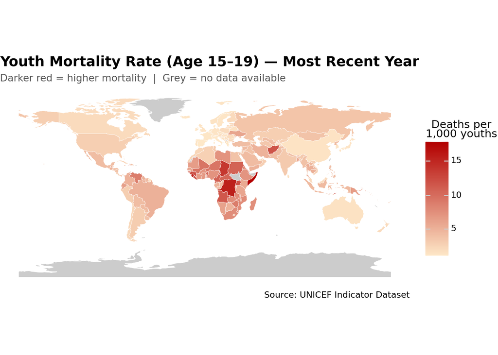

Figure 1: Most recent youth mortality rate (per 1,000) by country

```python
url = "https://naciscdn.org/naturalearth/110m/cultural/ne_110m_admin_0_countries.zip"
r = requests.get(url)
z = zipfile.ZipFile(io.BytesIO(r.content))
z.extractall("/tmp/ne_countries")

world = gpd.read_file("/tmp/ne_countries/ne_110m_admin_0_countries.shp")

latest = (
    ind_total
    .sort_values("time_period", ascending=False)
    .groupby("alpha_3_code", as_index=False)
    .first()
)[["alpha_3_code", "obs_value", "country"]]
latest.columns = ["iso_a3", "mortality_rate", "country"]

world_merged = world.merge(latest, left_on="ADM0_A3", right_on="iso_a3", how="left")

(
    ggplot(world_merged)
    + geom_map(aes(fill="mortality_rate"), color="white", size=0.15)
    + scale_fill_gradient(
        low      = "#fee8c8",
        high     = "#b30000",
        na_value = "#cccccc",
        name     = "Deaths per\n1,000 youths"
    )
    + coord_equal()
    + labs(
        title    = "Youth Mortality Rate (Age 15–19) — Most Recent Year",
        subtitle = "Darker red = higher mortality  |  Grey = no data available",
        caption  = "Source: UNICEF Indicator Dataset"
    )
    + theme_void()
    + theme(
        plot_title      = element_text(size=14, face="bold"),
        plot_subtitle   = element_text(size=10, color="#555555"),
        legend_position = "right"
    )
)
```

## 2. Bar Chart — The 15 Countries with Highest Youth Mortality

Not all countries are equal when it comes to protecting their young people. The chart below highlights the **15 nations with the highest average youth mortality rates** over the most recent five years of available data.

Several of the most-affected countries are *conflict-affected states* or nations with **severe poverty**, demonstrating the tight link between political instability and child welfare.

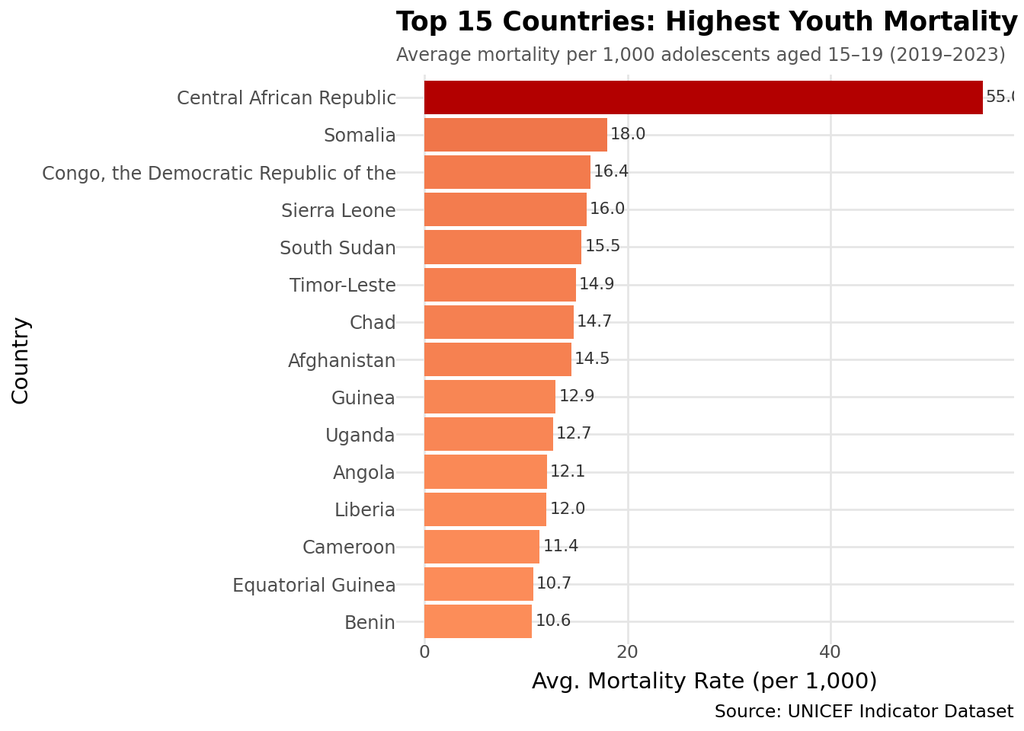

Figure 2: Top 15 countries by average youth mortality rate (most recent 5 years)

```python
max_year = ind_total["time_period"].max()
recent_5 = ind_total[ind_total["time_period"] >= max_year - 4]

top15 = (
    recent_5
    .groupby("country", as_index=False)["obs_value"]
    .mean()
    .sort_values("obs_value", ascending=False)
    .head(15)
)

top15["country"] = pd.Categorical(
    top15["country"],
    categories = top15.sort_values("obs_value")["country"].tolist(),
    ordered    = True
)

(
    ggplot(top15, aes(x="country", y="obs_value", fill="obs_value"))
    + geom_col()
    + coord_flip()
    + scale_fill_gradient(low="#fc8d59", high="#b30000")
    + guides(fill=False)
    + geom_text(
        aes(label="obs_value.round(1).astype(str)"),
        ha="left", nudge_y=0.3, size=8, color="#333333"
    )
    + labs(
        title    = "Top 15 Countries: Highest Youth Mortality Rates",
        subtitle = f"Average mortality per 1,000 adolescents aged 15–19 ({max_year-4}–{max_year})",
        x="Country", y="Avg. Mortality Rate (per 1,000)",
        caption  = "Source: UNICEF Indicator Dataset"
    )
    + theme_minimal()
    + theme(
        plot_title=element_text(size=13, face="bold"),
        plot_subtitle=element_text(size=9, color="#555555"),
        axis_text_y=element_text(size=9),
        panel_grid_minor=element_blank()
    )
)
```

## 3. Scatterplot — Does Wealth Protect Young Lives?

The scatterplot below plots each country’s **GDP per capita** against its **youth mortality rate**, with a regression line showing the overall trend.

The regression line confirms a strong **negative relationship** — as GDP per capita rises, youth mortality falls sharply. This underscores the need to address *economic inequality* as a root cause of preventable youth deaths.

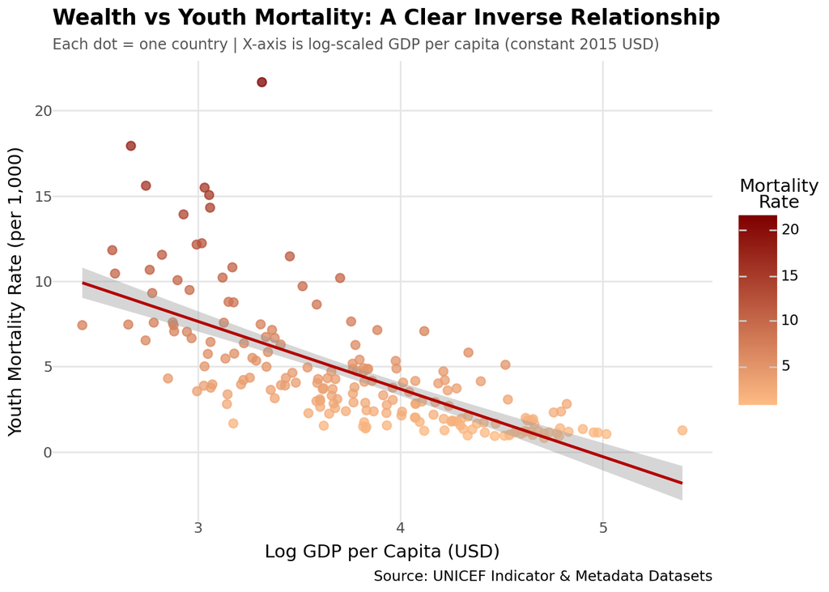

Figure 3: GDP per capita vs youth mortality rate with linear regression line

```python
latest_mortality = (
    ind_total
    .sort_values("time_period", ascending=False)
    .groupby("alpha_3_code", as_index=False)
    .first()
)[["alpha_3_code", "obs_value", "country"]]

gdp_latest = (
    metadata
    .dropna(subset=["GDP per capita (constant 2015 US$)"])
    .sort_values("year", ascending=False)
    .groupby("alpha_3_code", as_index=False)
    .first()
)[["alpha_3_code", "GDP per capita (constant 2015 US$)"]]
gdp_latest.columns = ["alpha_3_code", "gdp_per_capita"]

scatter_df = latest_mortality.merge(gdp_latest, on="alpha_3_code", how="inner")
scatter_df  = scatter_df.dropna(subset=["gdp_per_capita", "obs_value"])
scatter_df["log_gdp"] = np.log10(scatter_df["gdp_per_capita"])

(
    ggplot(scatter_df, aes(x="log_gdp", y="obs_value"))
    + geom_point(aes(color="obs_value"), alpha=0.75, size=2.5)
    + geom_smooth(method="lm", color="#b30000", se=True, size=1)
    + scale_color_gradient(low="#fdbb84", high="#7f0000", name="Mortality\nRate")
    + labs(
        title    = "Wealth vs Youth Mortality: A Clear Inverse Relationship",
        subtitle = "Each dot = one country | X-axis is log-scaled GDP per capita (constant 2015 USD)",
        x="Log GDP per Capita (USD)", y="Youth Mortality Rate (per 1,000)",
        caption  = "Source: UNICEF Indicator & Metadata Datasets"
    )
    + theme_minimal()
    + theme(
        plot_title=element_text(size=13, face="bold"),
        plot_subtitle=element_text(size=9, color="#555555"),
        panel_grid_minor=element_blank()
    )
)
```

## 4. Time-Series — Progress Over Time

The final chart tracks **global progress** in reducing youth mortality from 1990 to 2023, showing trends separately for **male** and **female** adolescents.

While there has been meaningful *progress since 1990*, male adolescent mortality consistently exceeds female mortality — a gap that reflects higher exposure of young men to:

- **Violence and conflict**
- **Road traffic accidents**
- **Risk-taking behaviour**

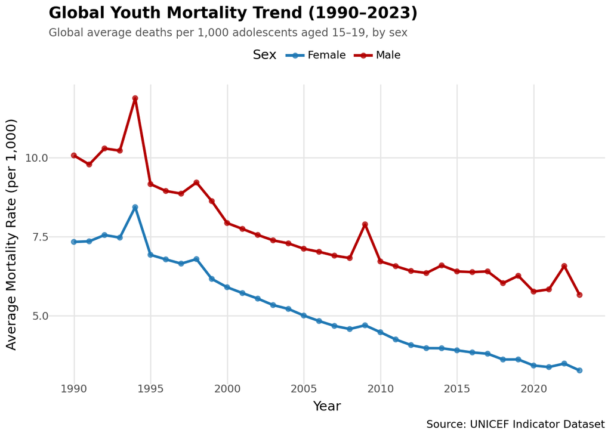

Figure 4: Global average youth mortality rate trend by sex (1990–2023)

```python
ts_data = indicator[indicator["sex"].isin(["Male", "Female"])].copy()
ts_data["time_period"] = ts_data["time_period"].astype(int)

ts_avg = (
    ts_data
    .groupby(["time_period", "sex"], as_index=False)["obs_value"]
    .mean()
)

(
    ggplot(ts_avg, aes(x="time_period", y="obs_value", color="sex", group="sex"))
    + geom_line(size=1.2)
    + geom_point(size=1.8, alpha=0.7)
    + scale_color_manual(
        values={"Male": "#b30000", "Female": "#1f78b4"},
        name="Sex"
    )
    + scale_x_continuous(breaks=list(range(1990, 2025, 5)))
    + labs(
        title    = "Global Youth Mortality Trend (1990–2023)",
        subtitle = "Global average deaths per 1,000 adolescents aged 15–19, by sex",
        x="Year", y="Average Mortality Rate (per 1,000)",
        caption  = "Source: UNICEF Indicator Dataset"
    )
    + theme_minimal()
    + theme(
        plot_title=element_text(size=13, face="bold"),
        plot_subtitle=element_text(size=9, color="#555555"),
        panel_grid_minor=element_blank(),
        legend_position="top"
    )
)
```

## Conclusion

The data tells a clear and urgent story:

- **Where you are born** largely determines your chances of surviving adolescence
- **Economic development** is one of the strongest protectors of young lives
- **Progress has been made**, but it is uneven and insufficient
- **Young men** face systematically higher mortality risks than young women

UNICEF and its partners must continue to direct resources toward the nations where adolescent mortality remains tragically high.

*Report prepared using UNICEF open data. Visualisations created with **plotnine** in Python/Quarto.*